# Effects of Milkweed Populations and Air Temperature on Monarch Butterfly Populations

# Names

- Ethan Kim
- Jonah Davis
- Joseph Byrd
- Justin He
- Rohun Kulshrestha

# Abstract

# Research Question

Can aggregate air temperature and milkweed population data predict the migration patterns and population density of monarch butterflies over time?

# Background and Prior Work

Our project aims to build upon the work of the aforementioned studies, employing machine learning techniques to accurately predict Monarch migration patterns in response to climate change, milkweed density, and other confounding variables that may be uncovered throughout the course of this research.

1. ^ Lemoine, N. (2015). Climate Change May Alter Breeding Ground Distributions of Eastern Migratory Monarchs (*Danaus plexippus*) via Range Expansion of Asclepias Host Plants. PLoS ONE, 10. https://doi.org/10.1371/journal.pone.0118614.
2. ^ Loarie, Scott. “150,000,000 Observations on Inaturalist!” iNaturalist, iNaturalist, 28 July 2023, www.inaturalist.org/blog/82561-150-000-000-observations-on-inaturalist.
3. ^ Flockhart, D., Pichancourt, J., Norris, D., & Martin, T. (2015). Unravelling the annual cycle in a migratory animal: breeding-season habitat loss drives population declines of monarch butterflies.. The Journal of animal ecology, 84 1, 155-65 . https://doi.org/10.1111/1365-2656.12253.
4. ^ Oberhauser, K., Prysby, M., Mattila, H., Stanley-Horn, D., Sears, M., Dively, G., Olson, E., Pleasants, J., Lam, W., & Hellmich, R. (2001). Temporal and spatial overlap between monarch larvae and corn pollen. Proceedings of the National Academy of Sciences of the United States of America, 98, 11913 - 11918. https://doi.org/10.1073/pnas.211234298.
5. ^ https://devpost.com/software/a-climate-based-analysis-of-monarch-butterfly-patterns
6. ^ Using Deep Learning to Count Monarch Butterflies in Dense Clusters, Shruti Patel, Amogh Kulkari, Ayan Mukhopadhyay, Karuna Gujar, Jaap de Roode bioRxiv 2021.07.23.453502; doi: https://doi.org/10.1101/2021.07.23.453502
7. ^ https://medium.com/@jakeamahr/using-rgbif-to-visualize-annual-monarch-butterfly-migrations-f34a335b77f1
8. ^ https://adapt136.ucsc.edu/taxa/invertebrates/too-cold-for-comfort-how-climate-change-is-affecting-the-monarch-butterfly
9. ^ “Milkweed Faqs.” The Xerces Society for Invertebrate Conservation, www.xerces.org/milkweed-faq#:~:text=In%20contrast%2C%20the%20majority%20of,during%20late%20fall%20and%20winter. Accessed 10 Mar. 2024.
10. ^ Slusser, Isis Howard and Kailee, et al. Endangered Species Conservation Biologist. “5 Monarch Migration Facts.” Xerces Society, www.xerces.org/blog/5-monarch-migration-facts. Accessed 10 Mar. 2024.
11. ^ Lindsey, Daulman (2024). "Climate Change: Global Temperature". https://www.climate.gov/news-features/understanding-climate/climate-change-global-temperature#:~:text=It%20was%202.12%20°F,F%20(13.9°C)

# Hypothesis

H<sub>0</sub>: Historic aggregate air temperature and milkweed population data cannot predict the migration patterns and population density of Monarch butterflies in North America.

H<sub>a1</sub>: Historic aggregate air temperature data can predict the migration patterns and population density of Monarch butterflies in North America.

H<sub>a2</sub>: Milkweed population data can predict the migration patterns and population density of Monarch butterflies in North America.

Given the scope of the relevant literature and available datasets, we believe that we can produce a model that can effectively predict the migration patterns and population density of Monarch butterflies in North America. Considering that the reliable tracking of Monarch migration patterns has been demonstrated, we feel confident in predicting these patterns with the added factors of climate change and milkweed density.

# Data

## Data overview

- Dataset #1
  - Dataset Name: iNaturalist Monarch Butterfly Observations
  - Link to the dataset: https://www.inaturalist.org/observations?d1=03-01-2008&d2=2024-02-01&place_id=97394&taxon_id=48662&verifiable=any
  - Number of observations: 278256
  - Number of variables: 39
- Dataset #2
  - Dataset Name: iNaturalist Milkweed Observations
  - Link to the dataset: https://www.inaturalist.org/observations?d1=03-01-2008&d2=2024-02-01&place_id=97394&taxon_id=47906&verifiable=any
  - Number of observations: 352212
  - Number of variables: 39
- Dataset #3
  - Dataset Name: Berkeley Earth Global Gridded Temperature Data: Global Monthly Land + Ocean Average Temperature with Air Temperatures at Sea Ice (Recommended; 1850 – Recent)
  - Link to the dataset: https://berkeleyearth.org/data/
  - Number of observations: 135302400
  - Number of variables: 4

The datasets from iNaturalist contain user-submitted observations of Monarch butterflies and milkweed plants. We queried the data to filter for observations that are only in North America from 2008-03-01 to 20204-02-01. The iNaturalist datasets contain many unnecessary variables (user_id, taxon, etc.) that we will likely drop, as we are mainly interested in the date observed, latitutude, and longitude of each observation for each species.

The dataset from Berkeley Earth contains average air temperatures across a latitude-longitude grid from 1850 to the present. The only variables are time, latitude, longitude, and temperature, all of which we will keep. It should be noted that the temperature is reported in degrees Celsius as anomolies relative to the January 1951-December 1980 average. A 30-year baseline period is standard for modeling climate change <sup>11</sup>, and the global average air temperature during the 1951-1980 period was 14 degrees Celsius <sup>12</sup>. Because this dataset has observations from around the globe over a large time frame, there will be many rows that are outside of North America and/or outside the date range that will be dropped.

Since we are modeling whether milkweed population data and historical climate data can predict the population of Monarch butterflies, we will create and assign regions based on the latitude and longitude values and group the data by month and region.

11. ^ Working Group I: The Scientific Basis. *The Intergovernmental Panel on Climate Change*. https://archive.ipcc.ch/ipccreports/tar/wg1/483.htm
12. ^ World of Change: Global Temperatures. *NASA Earth Observatory*. https://earthobservatory.nasa.gov/world-of-change/global-temperatures#:~:text=The%20data%20reflect%20how%20much,several%20tenths%20of%20a%20degree.)

## Setup

### Install required libraries

Run this command in terminal

```
!pip install pandas xarray folium scikit-learn netCDF4 seaborn geopandas pysal splot pmdarima
```

### Import required libraries

```python
# imports
import pandas as pd
import numpy as np
import matplotlib.pyplot as plt
import xarray as xr
from datetime import datetime, timedelta
import folium
from folium.plugins import HeatMap
from sklearn.linear_model import LinearRegression
from sklearn.cluster import KMeans
import seaborn as sns
import geopandas as gpd
from pysal.lib import weights
from pysal.explore import esda
from splot.esda import moran_scatterplot
from splot.esda import plot_local_autocorrelation
from splot.esda import lisa_cluster
from pmdarima import auto_arima
from shapely.geometry import Point, Polygon
```

## iNaturalist Datasets (Monarch and Milkweed)

These datasets required minimal cleaning, simply keeping the columns we want, dropping null rows, renaming the 'observed_on' column to 'time', and casting the 'time' values from string to datetime objects.

### Importing datasets

```python
# monarch butterfly csv files from iNaturalist
monarch_2008_2021 = pd.read_csv('monarch_2008-2021.csv')
monarch_2021_2024 = pd.read_csv('monarch_2021-2024.csv')
monarch_df = pd.concat([monarch_2008_2021, monarch_2021_2024], ignore_index=True)

# milkweed butterfly csv files from iNaturalist
milkweed_2008_2021 = pd.read_csv('milkweed_2008-2021.csv')
milkweed_2021_2024 = pd.read_csv('milkweed_2021-2024.csv')
milkweed_df = pd.concat([milkweed_2008_2021, milkweed_2021_2024], ignore_index=True)
```

### Cleaning datasets

```python
#cleaning monarch data

# drop unecessary columns
columns_to_keep = ['observed_on', 'latitude', 'longitude']
monarch_df = monarch_df[columns_to_keep]

# drop null rows
monarch_df = monarch_df.dropna()

# rename observed_on column to time
monarch_df.rename(columns={'observed_on': 'time'}, inplace=True)

# change 'time' values from string to datetime object
monarch_df['time'] = pd.to_datetime(monarch_df['time'])


#cleaning milkweed data

# drop unecessary columns
columns_to_keep = ['observed_on', 'latitude', 'longitude']
milkweed_df = milkweed_df[columns_to_keep]

# drop null rows
milkweed_df = milkweed_df.dropna()

# rename observed_on column to time
milkweed_df.rename(columns={'observed_on': 'time'}, inplace=True)

# change 'time' values from string to datetime object
milkweed_df['time'] = pd.to_datetime(milkweed_df['time'])
```

## Temperature Dataset

This dataset required us to convert the 'time' column from its given format of fractional years to a datetime object. This required the writing of a separate function. In addition, many rows had to be filtered out because they were outside the date and coordinate range of our project. The latitude and longitude variables also had to be cast to float64 to match the type in the monarch_df and milkweed_df dataframes.

### Importing dataset

```python
#open NetCDF file and access 'temperature' variable
dataset = xr.open_dataset('Land_and_Ocean_LatLong1.nc')
temperature_data = dataset['temperature']

# convert DataArray to a pandas DataFrame
temperature_df = temperature_data.to_dataframe()

# reset the index to keep coordinates as columns
temperature_df.reset_index(inplace=True)
```

### Cleaning dataset

```python
# helper function to check if year is leap year
def is_leap(year):
    return (year % 4 == 0 and (year % 400 == 0 or year % 100 != 0))

# function to convert from fractional year to datetime object taking leap years into account
def convert_fractional_year(frac_year):
    if isinstance(frac_year, datetime):
        return frac_year
    year = int(frac_year)
    frac = frac_year - year
    if (year % 4):
        days_in_year = 366
    else:
        days_in_year = 365
    days_passed = int(days_in_year * frac)
    start_date = datetime(year, 1, 1)
    date = start_date + timedelta(days=days_passed)
    return date

# drop null rows
temperature_df = temperature_df.dropna()

# drop rows not in latitude-longitude range
min_lat = min(monarch_df['latitude'].min(), milkweed_df['latitude'].min())
max_lat = max(monarch_df['latitude'].max(), milkweed_df['latitude'].max())
min_long = min(monarch_df['longitude'].min(), milkweed_df['longitude'].min())
max_long = max(monarch_df['longitude'].max(), milkweed_df['longitude'].max())
temperature_df = temperature_df[(temperature_df['latitude'] >= min_lat) & (temperature_df['latitude'] <= max_lat)]
temperature_df = temperature_df[(temperature_df['longitude'] >= min_long) & (temperature_df['longitude'] <= max_long)]

# convert time from fractional year to YYYY-MM-DD format
temperature_df['time'] = temperature_df['time'].apply(convert_fractional_year)

# drop rows not in date range
start_date = min(monarch_df['time'].min(), milkweed_df['time'].min())
end_date = max(monarch_df['time'].max(), milkweed_df['time'].max())
temperature_df = temperature_df[(temperature_df['time'] >= start_date) & (temperature_df['time'] <= end_date)]

# change latitude and longitude value types to float64
temperature_df[['latitude', 'longitude']] = temperature_df[['latitude', 'longitude']].astype(float)
```

## Merging data

To create the final dataframe, we wanted to create a region column. Rather than make the region based off of state/province, we decided to choose the region with K-means clustering (note: the number of clusters that will be used is undecided and may be adjusted in the future). We then grouped the temperature, milkweed, and monarch data by month and region. We also created a new column which is the actual temperature in degrees Celsius, rather than the temperature measured as anomolies relative to the baseline period.

### K-means clustering

```python
# combine all latitude and longitude data from dataframes
coordinates = np.vstack((
    temperature_df[['latitude', 'longitude']].values,
    milkweed_df[['latitude', 'longitude']].values,
    monarch_df[['latitude', 'longitude']].values))

# perform K-means clustering
num_clusters = 50
kmeans = KMeans(n_clusters=num_clusters, random_state=42)
kmeans.fit(coordinates)

# assign clusters as regions back to each dataframe
temperature_df['region'] = kmeans.predict(temperature_df[['latitude', 'longitude']].astype(float))
milkweed_df['region'] = kmeans.predict(milkweed_df[['latitude', 'longitude']])
monarch_df['region'] = kmeans.predict(monarch_df[['latitude', 'longitude']])
```

```python
# aggregate temperature data on a monthly basis by region
temperature_monthly_avg = temperature_df.groupby(['region', pd.Grouper(key='time', freq='M')]).temperature.mean().reset_index()

# aggregate milkweed presence on a monthly basis by region
milkweed_count = milkweed_df.groupby(['region', pd.Grouper(key='time', freq='M')]).size().reset_index(name='milkweed_count')

# aggregate monarch counts on a monthly basis by region
monarch_monthly_counts = monarch_df.groupby(['region', pd.Grouper(key='time', freq='M')]).size().reset_index(name='monarch_count')

# merge aggregated temperature and milkweed presence on region and time
features_df = pd.merge(temperature_monthly_avg, milkweed_count, on=['region', 'time'], how='outer').fillna({'presence': 0})

# merge the above with monarch counts to include monarch population data
final_df = pd.merge(features_df, monarch_monthly_counts, on=['region', 'time'], how='left').fillna({'monarch_count': 0})

# drop null rows
final_df = final_df.dropna()

# create new column called actual_temperature which is the temperature as an anomoly plus the baseline average
baseline_temperature = 14
final_df['actual_temperature'] = final_df['temperature'] + baseline_temperature
```

```python
final_df.head()
```

|  | region | time | temperature | milkweed_count | monarch_count | actual_temperature |
| --- | --- | --- | --- | --- | --- | --- |
| 3 | 0 | 2008-06-30 | 1.021528 | 1.0 | 4.0 | 15.021527 |
| 4 | 0 | 2008-07-31 | 0.441387 | 9.0 | 3.0 | 14.441387 |
| 5 | 0 | 2008-08-31 | 0.283195 | 1.0 | 5.0 | 14.283195 |
| 6 | 0 | 2008-09-30 | 1.357105 | 1.0 | 1.0 | 15.357105 |
| 7 | 0 | 2008-10-31 | -0.155978 | 1.0 | 0.0 | 13.844023 |

# Results

## Exploratory Data Analysis

### Temperature

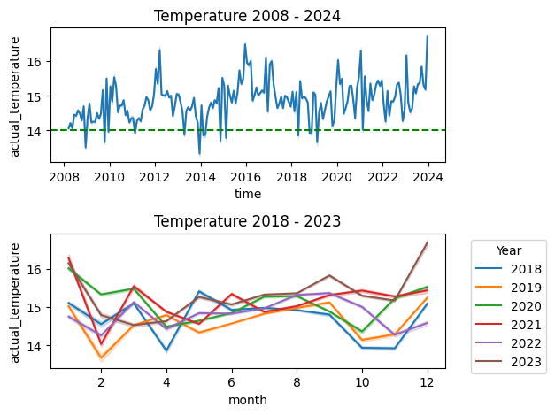

```python
# lets add the actual temperature for visualizations
baseline_temperature = 14

temperature_df['actual_temperature'] = temperature_df['temperature'] + baseline_temperature

# plotting figures
fig, axes = plt.subplots(2,1)

# For figure 1, plots the temperature over time
sns.lineplot(data = temperature_df, x = 'time', y = 'actual_temperature',
            ax=axes[0])
# adds baseline temperature as line
axes[0].axhline(y = baseline_temperature, color ='g', linestyle = '--')
axes[0].set_title('Temperature 2008 - 2024')


# for figure 2 lets plot the temps for 2018-2023
years = [2018, 2019, 2020, 2021, 2022, 2023]

# plots each year individually
for item in years:
    year_data = temperature_df[temperature_df['time'].dt.year == item].copy()
    year_data['month'] = year_data['time'].dt.month

    sns.lineplot(data = year_data, x = 'month', y ='actual_temperature',
                 ax=axes[1], label = str(item))

axes[1].set_title('Temperature 2018 - 2023')
axes[1].legend(title='Year', bbox_to_anchor=(1.05, 1), loc='upper left')


plt.tight_layout()
```

We can see that the annual temperature from these data are noisy, and it is difficult to see an overall pattern. This is however an average across a wide geography (North America, as well as the surrounding oceans). It would be useful to visulize these data geospatially.

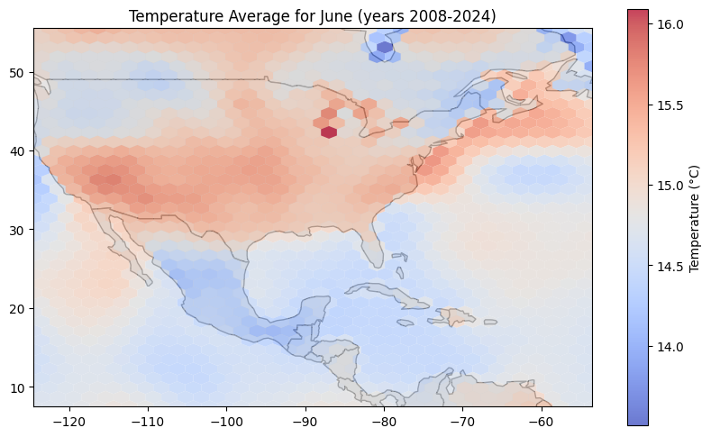

```python
# lets create a temperature subset
temp_sub = temperature_df[temperature_df['time'].dt.month == 6]

# gets built in world map background from geopandas
world = gpd.read_file(gpd.datasets.get_path('naturalearth_lowres'))

# plots the world map background
fig, ax = plt.subplots(1, 1, figsize=(10, 6))
world.plot(ax=ax, color='lightgrey', edgecolor='black')

temp = ax.hexbin(temp_sub['longitude'], temp_sub['latitude'],
                 gridsize = 35, C = temp_sub['actual_temperature'], cmap = 'coolwarm',
                 edgecolors = None, linewidths = 0.5, alpha = .75)


# adds a legend for temperature data
cbar = plt.colorbar(temp, ax=ax, orientation='vertical')
cbar.set_label('Temperature (°C)')

ax.set_xlim(temperature_df['longitude'].min(), temperature_df['longitude'].max())
ax.set_ylim(temperature_df['latitude'].min(), temperature_df['latitude'].max())

ax.set_title('Temperature Average for June (years 2008-2024)')

# plt.tight_layout()
plt.show()
```

The temperature set is shows what we would expect for temperature in terms of seasonality. But the temperature axes is in terms of difference to a baseline (14 degrees) so we want to fix that for our final dataframe to make our results easier to interpret. The baseline being 14 degrees celsius (57.2 degrees F) makes sense as the global surface temperature average is around 13.9 degrees<sup>11</sup>.

### Exploring Monarch and Milkweed observations

To compare monarchs and milkweeds, lets create a shared species dataframe.

```python
# creates a species column to merge together monarch and milkweed observations
sub_monarch_df = monarch_df
sub_monarch_df['species'] = 'monarch'

sub_milkweed_df = milkweed_df
sub_milkweed_df['species'] = 'milkweed'

# merge observations together to a species df
species_df = pd.concat([monarch_df, milkweed_df], ignore_index=True)
species_df
```

|  | time | latitude | longitude | region | species |
| --- | --- | --- | --- | --- | --- |
| 0 | 2009-03-01 | 26.078794 | -80.278366 | 17 | monarch |
| 1 | 2009-09-13 | 26.080471 | -80.277916 | 17 | monarch |
| 2 | 2009-06-08 | 35.557690 | -121.081589 | 38 | monarch |
| 3 | 2010-08-28 | 40.241203 | -76.056328 | 41 | monarch |
| 4 | 2009-06-09 | 38.566663 | -122.684812 | 38 | monarch |
| ... | ... | ... | ... | ... | ... |
| 594301 | 2024-01-02 | 41.700092 | -81.250438 | 0 | milkweed |
| 594302 | 2022-09-25 | 45.383540 | -74.195939 | 13 | milkweed |
| 594303 | 2023-06-21 | 38.875559 | -96.950733 | 27 | milkweed |
| 594304 | 2023-05-24 | 35.845706 | -78.795036 | 5 | milkweed |
| 594305 | 2021-07-26 | 43.872866 | -79.236480 | 44 | milkweed |

594306 rows × 5 columns

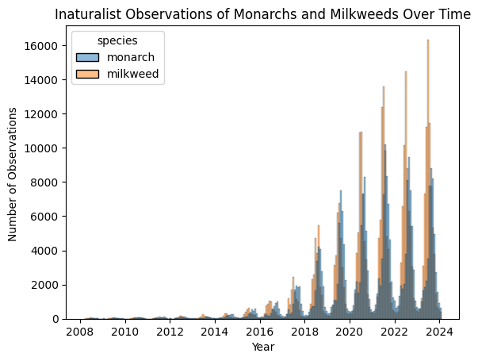

```python
histplot = sns.histplot(data=species_df, x = 'time', hue='species')

histplot.set_title('Inaturalist Observations of Monarchs and Milkweeds Over Time')
histplot.set_xlabel('Year')
histplot.set_ylabel('Number of Observations ')
plt.show()
```

There is an interesting cyclic pattern to these data, and we can see that the number of observations across the board rises exponentially.  
We can assume there would be some variation in observations because of seasonality. But it seems that there is another variable affecting the plot.  
From Inaturalist we can see that the number of inaturalist users has risen in a similar way, and also the number of inaturalist observations as a whole behaves in a seasonal way<sup>2</sup>. We will keep this in mind for our analysis as a potential bias to the data.

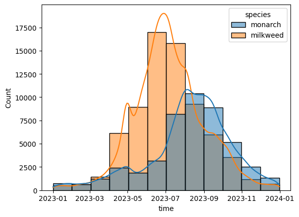

```python
sub_species_df = species_df[species_df['time'].dt.year == 2023]
sub_species_df
sns.histplot(data=sub_species_df, x = 'time', hue='species', bins=12, kde=True)
```

Narrowing down to just one year (2023), We can see that milkweed observations preceed monarch observations.

Milkweeds are decideous, and do not have foliage during late fall and winter. They do bloom from June to August which can explain the spike in observations over that period<sup>9</sup>.

As far as Monarchs go, their abundance is a bit more complicated. However it does make sense to see more observations during the summer months as monarchs migrate from south America (and inland from the coast of California)<sup>10</sup>.

We will need to use spatial visualizations to see if our data shares this expected pattern.

### Merging Temperature and Species Observations

Lets combine our species observations and the temperature dataframe to search for temperature dependent patterns.

```python
# combine all latitude and longitude data from dataframes
coordinates = np.vstack((
    temperature_df[['latitude', 'longitude']].values,
    milkweed_df[['latitude', 'longitude']].values,
    monarch_df[['latitude', 'longitude']].values))

# perform K-means clustering
num_clusters = 50  # to be adjusted
kmeans = KMeans(n_clusters=num_clusters, random_state=42)
kmeans.fit(coordinates)

# assign clusters as regions back to each dataframe
temperature_df['region'] = kmeans.predict(temperature_df[['latitude', 'longitude']].astype(float))
milkweed_df['region'] = kmeans.predict(milkweed_df[['latitude', 'longitude']])
monarch_df['region'] = kmeans.predict(monarch_df[['latitude', 'longitude']])
```

```python
# aggregate temperature data on a monthly basis by region
temperature_monthly_avg = temperature_df.groupby(['region', pd.Grouper(key='time', freq='M')]).temperature.mean().reset_index()

# aggregate milkweed presence on a monthly basis by region
milkweed_presence = milkweed_df.assign(presence=1).groupby(['region', pd.Grouper(key='time', freq='M')]).presence.max().reset_index()

# aggregate monarch counts on a monthly basis by region
monarch_monthly_counts = monarch_df.groupby(['region', pd.Grouper(key='time', freq='M')]).size().reset_index(name='monarch_count')

# merge aggregated temperature and milkweed presence on region and time
features_df = pd.merge(temperature_monthly_avg, milkweed_presence, on=['region', 'time'], how='outer').fillna({'presence': 0})

# merge the above with monarch counts to include monarch population data
final_df = pd.merge(features_df, monarch_monthly_counts, on=['region', 'time'], how='left').fillna({'monarch_count': 0})

# drop null rows
final_df = final_df.dropna()

# create new column called actual_temperature which is the temperature as an anomoly plus the baseline average
baseline_temperature = 14
final_df['actual_temperature'] = final_df['temperature'] + baseline_temperature
```

To create the final dataframe, we wanted to create a region column. Rather than make the region based off of state/province, we decided to choose the region with K-means clustering (note: the number of clusters that will be used is undecided and may be adjusted in the future). We then grouped the temperature, milkweed, and monarch data by month and region. We also created a new column which is the actual temperature in degrees Celsius, rather than the temperature measured as anomolies relative to the baseline period.  
Now that our species observations and the temperature dataframe are merged, lets search for temperature dependent patterns.

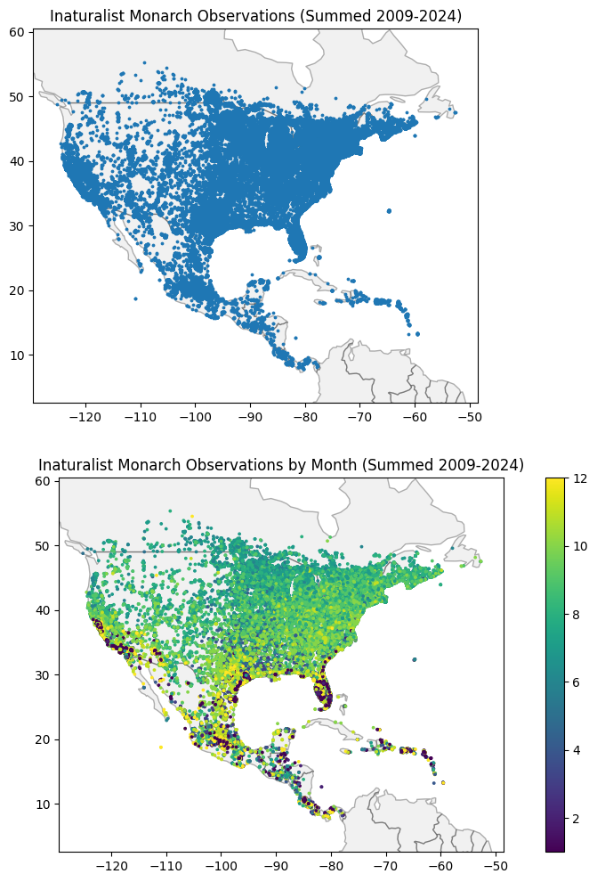

```python
geometry = [Point(xy) for xy in zip(monarch_df['longitude'], monarch_df['latitude'])]
gfd= gpd.GeoDataFrame(monarch_df, geometry = geometry, crs = 'EPSG:4326')

fig, axes = plt.subplots(2, 1, figsize=(12, 12))

# plots the world map background on the top figure
world.plot(ax=axes[0], color='lightgrey', edgecolor='black', alpha = .30)
# set the limits of the world plot
# buffer gives some more space for the min/max of the data
buffer = 5
axes[0].set_xlim(temperature_df['longitude'].min() - buffer, temperature_df['longitude'].max() + buffer)
axes[0].set_ylim(temperature_df['latitude'].min() - buffer, temperature_df['latitude'].max() + buffer)

# plots the top figure - monarch data summed 2009-2024
map1 = gfd.plot(ax=axes[0], markersize = 3)
map1.set_title('Inaturalist Monarch Observations (Summed 2009-2024)')


# plots the world map background on the bottom figure
world.plot(ax=axes[1], color='lightgrey', edgecolor='black', alpha = .30)
# set the limits of the world plot
# buffer gives some more space for the min/max of the data
buffer = 5
axes[1].set_xlim(temperature_df['longitude'].min() - buffer, temperature_df['longitude'].max() + buffer)
axes[1].set_ylim(temperature_df['latitude'].min() - buffer, temperature_df['latitude'].max() + buffer)


# plots the bottom figure - monarch data colored by month
map2 = gfd.plot(ax=axes[1], column = monarch_df['time'].dt.month,
              markersize = 3, legend = True)
map2.set_title('Inaturalist Monarch Observations by Month (Summed 2009-2024)')
```

The top figure shows us that monarch observations are not equally distirbuted across North America, and there is a considerable gap in the data towards the west end of the U.S. This is more of a gap than would be expected from monarch migrations as summed through 2009-2024. This bias could be from the distirbution of Inaturalist users being in more populated areas.

The bottom figure replots the same plots but with a gradient representing the month the observation was taken. We can see that there seems to be more observations in the south/coast of California in the winter months, and less in the summer. This is great, as this follows the pattern we expect of migration!<sup>10</sup>

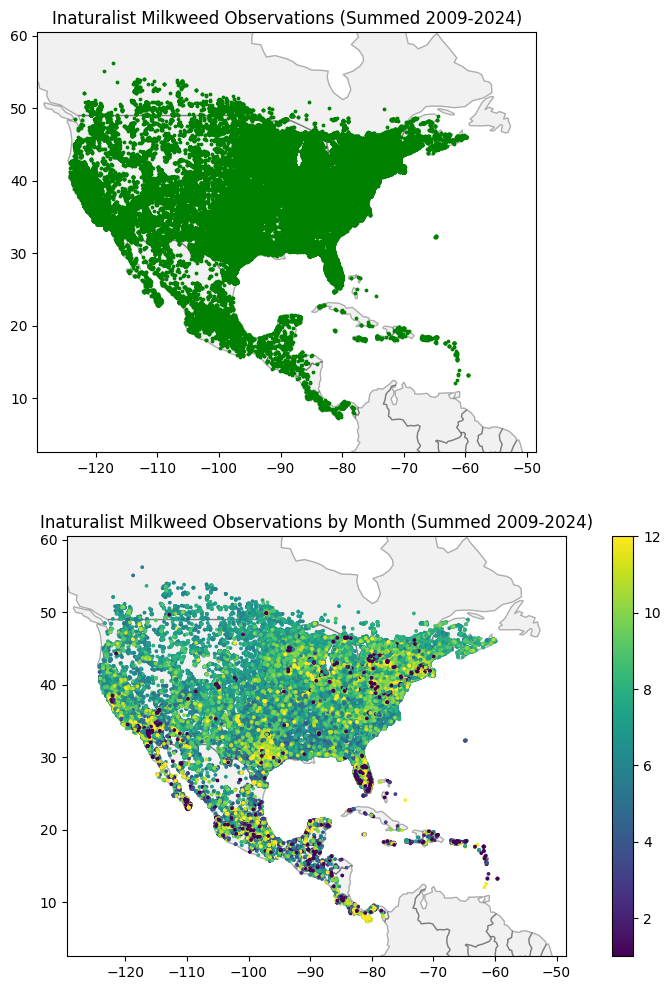

```python
geometry = [Point(xy) for xy in zip(milkweed_df['longitude'], milkweed_df['latitude'])]
gfd= gpd.GeoDataFrame(milkweed_df, geometry = geometry, crs = 'EPSG:4326')

fig, axes = plt.subplots(2, 1, figsize=(12, 12))

#plots the world map background on the top figure
world.plot(ax=axes[0], color='lightgrey', edgecolor='black', alpha = .30)
#set the limits of the world plot
#buffer gives some more space for the min/max of the data
buffer = 5
axes[0].set_xlim(temperature_df['longitude'].min() - buffer, temperature_df['longitude'].max() + buffer)
axes[0].set_ylim(temperature_df['latitude'].min() - buffer, temperature_df['latitude'].max() + buffer)

#plots the top figure - monarch data summed 2009-2024
map1 = gfd.plot(ax=axes[0], markersize = 3, color='green')
map1.set_title('Inaturalist Milkweed Observations (Summed 2009-2024)')


#plots the world map background on the bottom figure
world.plot(ax=axes[1], color='lightgrey', edgecolor='black', alpha = .30)
#set the limits of the world plot
#buffer gives some more space for the min/max of the data
buffer = 5
axes[1].set_xlim(temperature_df['longitude'].min() - buffer, temperature_df['longitude'].max() + buffer)
axes[1].set_ylim(temperature_df['latitude'].min() - buffer, temperature_df['latitude'].max() + buffer)


#plots the bottom figure - monarch data colored by month
map2 = gfd.plot(ax=axes[1], column = milkweed_df['time'].dt.month,
              markersize = 3, legend = True)
map2.set_title('Inaturalist Milkweed Observations by Month (Summed 2009-2024)')
```

Now comparing the same plot but with milkweed observations we would expect a relatively even distribution with little seasonal variation. However we still see some patches in north Mexico and the midwest. This further suggests bias in the observational data. But we can see from the bottom figure that there isn't much of a hollistic pattern to milkweed distributions by date.

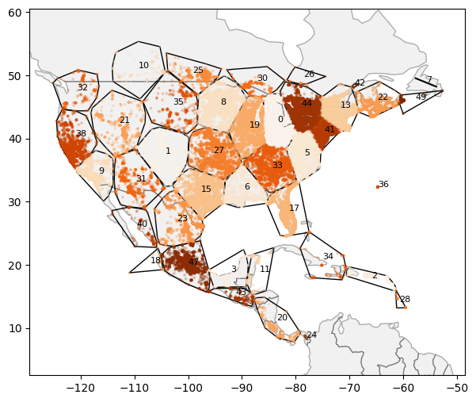

```python
# plots the world map background
fig, ax = plt.subplots(1, 1, figsize=(10, 6))

world.plot(ax=ax, color='lightgrey', edgecolor='black', alpha = .30)


# set the limits of the world plot
# buffer gives some more space for the min/max of the data
buffer = 5
ax.set_xlim(temperature_df['longitude'].min() - buffer, temperature_df['longitude'].max() + buffer)
ax.set_ylim(temperature_df['latitude'].min() - buffer, temperature_df['latitude'].max() + buffer)


# Create GeoDataFrame with individual points
geometry = [Point(xy) for xy in zip(monarch_df['longitude'], monarch_df['latitude'])]
gdf_points = gpd.GeoDataFrame(monarch_df, geometry=geometry, crs='EPSG:4326')

# Group monarch observations by 'region' and create convex hulls
region_hulls = gdf_points.groupby('region')['geometry'].apply(lambda x: x.unary_union.convex_hull).reset_index()
gdf_hulls = gpd.GeoDataFrame(region_hulls, geometry='geometry', crs='EPSG:4326')

#  Plot convex hulls
ax = gdf_hulls.plot(ax=ax, edgecolor='black', facecolor='none')

# Overlay monarch observations as points without edge color
gdf_points.plot(ax=ax, column = 'region', cmap = 'Oranges', markersize = 3, alpha = .2)

# Label regions
for idx, row in gdf_hulls.iterrows():
    ax.text(row.geometry.centroid.x, row.geometry.centroid.y, str(row['region']), fontsize=8)


# Show plot
plt.show()
```

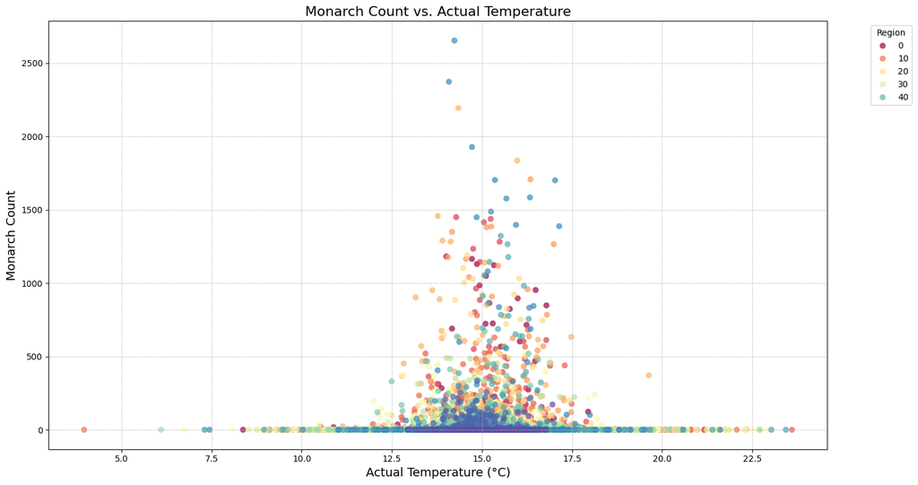

```python
# Visualization 1: Temperature vs. Monarch Count
plt.figure(figsize=(15, 8))
sns.scatterplot(data=final_df, x='actual_temperature', y='monarch_count', hue='region', palette='Spectral', s=50, edgecolor='none', alpha=0.7)
plt.title('Monarch Count vs. Actual Temperature', fontsize=16)
plt.xlabel('Actual Temperature (°C)', fontsize=14)
plt.ylabel('Monarch Count', fontsize=14)
plt.legend(title='Region', bbox_to_anchor=(1.05, 1), loc='upper left')
plt.grid(True, which='both', linestyle='--', linewidth=0.5)
plt.tight_layout()  # Adjust the plot to ensure the legend is in the best position
plt.show()
```

Plotting monarch observations per region (the plotted regions in this visualization are partitioned in multiples of 10 for clearer region discrimination) produces a nebulous cloud of points. Temperature-wise, most observations cluster within the range of 12.5 C to 17.5 C; Count-wise, most observations cluster within the range of 0 to 500 (with two notable outliers within the 2000 to 2500 range). There appears to be a non-linear association between monarch count and temperature given the scatterplot.

[figure not shown]

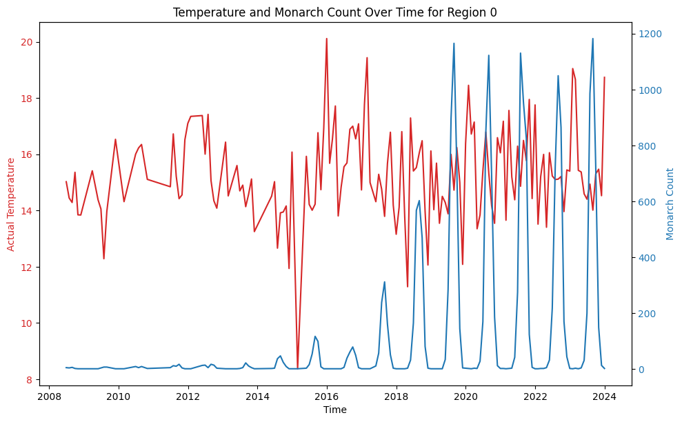

```python
# Visualization 2: Time Series of Milkweed Count and Monarch Count for a single region
region_to_visualize = 0  # Change this to visualize other regions
region_data = final_df[final_df['region'] == region_to_visualize].sort_values(by='time')

fig, ax1 = plt.subplots(figsize=(12, 6))
color = 'tab:blue'
ax1.set_xlabel('Time')
ax1.set_ylabel('Milkweed Count', color=color)
ax1.plot(region_data['time'], region_data['milkweed_count'], color=color)
ax1.tick_params(axis='y', labelcolor=color)

ax2 = ax1.twinx()
color = 'tab:red'
ax2.set_ylabel('Monarch Count', color=color)
ax2.plot(region_data['time'], region_data['monarch_count'], color=color)
ax2.tick_params(axis='y', labelcolor=color)

plt.title(f'Time Series of Milkweed and Monarch Count for Region {region_to_visualize}')
fig.tight_layout()
plt.show()

# Filter data for one region, for example, region 0
region_data = final_df[final_df['region'] == 0]

fig, ax1 = plt.subplots(figsize=(10, 6))

color = 'tab:red'
ax1.set_xlabel('Time')
ax1.set_ylabel('Actual Temperature', color=color)
ax1.plot(region_data['time'], region_data['actual_temperature'], color=color)
ax1.tick_params(axis='y', labelcolor=color)

ax2 = ax1.twinx()  # instantiate a second axes that shares the same x-axis
color = 'tab:blue'
ax2.set_ylabel('Monarch Count', color=color)  # we already handled the x-label with ax1
ax2.plot(region_data['time'], region_data['monarch_count'], color=color)
ax2.tick_params(axis='y', labelcolor=color)

fig.tight_layout()  # otherwise the right y-label is slightly clipped
plt.title('Temperature and Monarch Count Over Time for Region 0')
plt.show()
```

Plotting milkweed observations against monarch observations in a time series uncovers a strong association between the two. The shapes of both distributions mirror each other perfectly regarding the onset (and offset) of observation count proliferation. We might infer that as milkweed observations increase, so too do monarch observations--or vice versa--as they are interdependent in the ecosphere. Within the scope of our data this may not be the case. See the discussion section for further details.

Plotting monarch observations against air temperature paints a poor picture of the association. We might infer some patterns from the monarch distribution but none from air temperature.

### Trend Analysis

```python
final_df['year'] = final_df['time'].dt.year
summary_by_year = final_df.groupby('year').agg({
    'temperature': ['mean', 'std'],
    'milkweed_count': ['mean', 'std'],
    'monarch_count': ['mean', 'std'],
    'actual_temperature': ['mean', 'std']
})

summary_by_year = summary_by_year.reset_index()
summary_by_year
```

[output not shown]

Since there is a lack of monarch and milkweed observations between 2008 and 2018, subsequent analyses will focus on the years following. Furthermore, we will also analyze data per year to control for error introduced from the observation spikes.

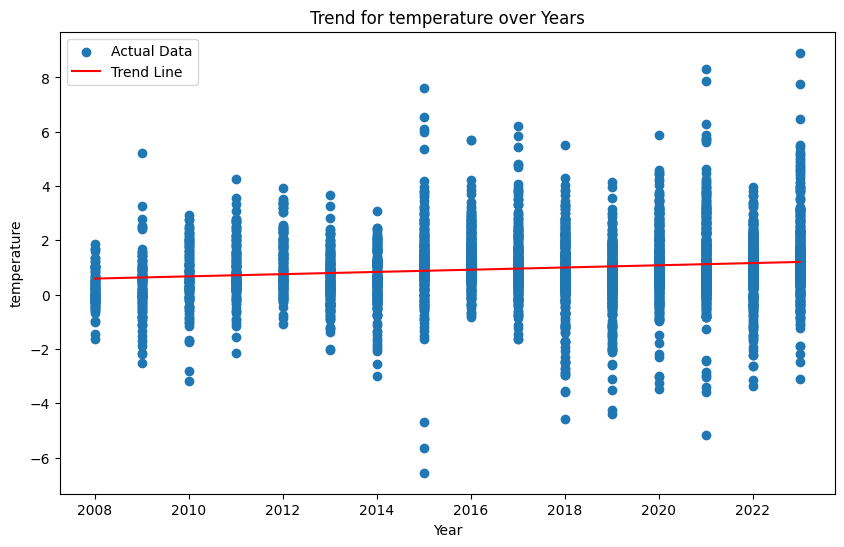

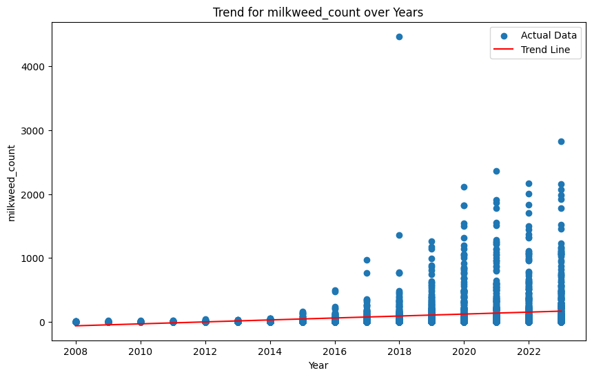

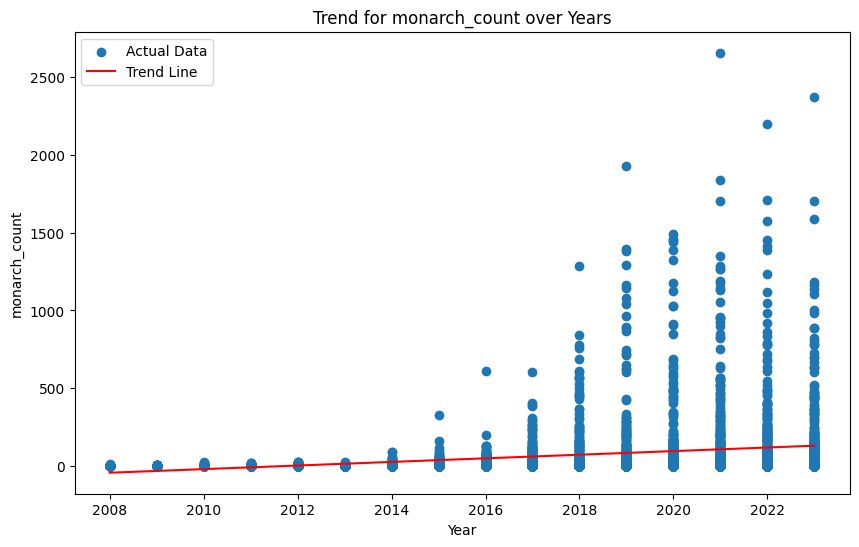

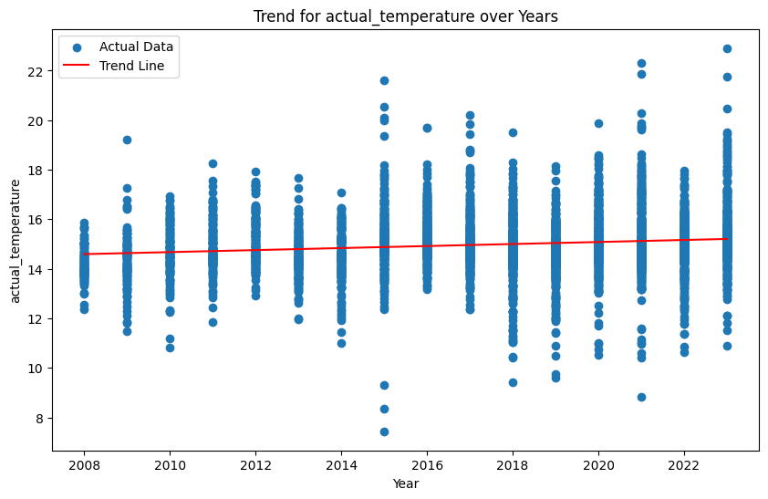

```python
model = LinearRegression()

# Dictionary to store the trends for each variable
trends = {}

# List of variables to analyze trends for
variables = ['temperature', 'milkweed_count', 'monarch_count', 'actual_temperature']

for variable in variables:
    # Reshape year for fitting the model
    X = final_df['year'].values.reshape(-1, 1)
    y = final_df[variable]

    # Fit the model
    model.fit(X, y)

    # Store the slope and intercept
    trends[variable] = {'slope': model.coef_[0], 'intercept': model.intercept_}

# Function to plot the trend
def plot_trend(df, variable, trend_info):
    plt.figure(figsize=(10, 6))
    plt.scatter(df['year'], df[variable], label='Actual Data')
    plt.plot(df['year'], df['year'] * trend_info['slope'] + trend_info['intercept'],
             color='red', label='Trend Line')
    plt.title(f'Trend for {variable} over Years')
    plt.xlabel('Year')
    plt.ylabel(variable)
    plt.legend()
    plt.show()

# Now plot the trends for each variable
for variable in variables:
    plot_trend(final_df, variable, trends[variable])
```

Regarding temperature from 2008 to 2022, the trend line is relatively flat, indicating a weak association between air temperature and time. The same can be said for milkweed and monarch observations--when starting in 2008, that is. If our plot started at ~2016, we would see a positive association between time and monarch/milkweed observations. From our data, we might infer that time has a notable effect on milkweed and monarch populations, this is not necessarily the case. See the discussion section for further analysis."

# Final Analysis

## Spatial Autocorrelation with Moran's I

Spatial autocorrelation can assess the degree of correlation between two spatial data sets. One way to measure this correlation is with a statistic known as Moran's I.

The Moran's I value ranges from -1 to 1:

Positive values indicate positive spatial autocorrelation (clustering of similar values)

Negative values indicate negative spatial autocorrelation (dispersion of dissimilar values)

A value near 0 suggests no spatial autocorrelation (random pattern)

Therefore a positive Moran's I should imply that our two variables are spatially correlated.

### Milkweed vs Monarch Moran's I

In order to minimize confounding variables in the data, we need to first completely randomize the dataframe before merging.

If there is zero spatial correlation, then we expect a Moran's I value of 0.

```python
import random

# Shuffle the indices of both dataframes
milkweed_indices = list(milkweed_df.index)
monarch_indices = list(monarch_df.index)
random.shuffle(milkweed_indices)
random.shuffle(monarch_indices)

# Use shuffled indices for merging
merged_df_milkweed = pd.merge(milkweed_df.iloc[milkweed_indices], monarch_df.iloc[monarch_indices], left_index=True, right_index=True, suffixes=('_milkweed', '_monarch'))

# Drop rows with missing geometries
merged_df_milkweed = merged_df_milkweed.dropna(subset=['latitude_milkweed', 'longitude_milkweed'])

#filter to year range 2019-2024 for more reliable data
merged_df = merged_df_milkweed[(merged_df_milkweed['time_milkweed'].dt.year >= 2019)]
merged_df = merged_df_milkweed[(merged_df_milkweed['time_monarch'].dt.year >= 2019)]

#take a sample of merged_df to minimize computation time
sample_df_milkweed = merged_df.sample(10000, random_state=53)
sample_df_milkweed.head()
```

|  | time_milkweed | latitude_milkweed | longitude_milkweed | region_milkweed | species_milkweed | time_monarch | latitude_monarch | longitude_monarch | region_monarch | species_monarch |
| --- | --- | --- | --- | --- | --- | --- | --- | --- | --- | --- |
| 184046 | 2021-08-28 | 44.943438 | -93.258052 | 26 | milkweed | 2022-07-22 | 38.675709 | -77.201230 | 22 | monarch |
| 157051 | 2021-06-26 | 39.143600 | -95.246407 | 38 | milkweed | 2021-09-21 | 39.740149 | -86.273655 | 46 | monarch |
| 239241 | 2022-08-20 | 25.696395 | -80.371650 | 15 | milkweed | 2023-08-11 | 44.381633 | -77.744325 | 39 | monarch |
| 106828 | 2020-07-19 | 39.439708 | -76.283255 | 3 | milkweed | 2020-09-16 | 42.381949 | -87.837560 | 46 | monarch |
| 237002 | 2022-08-12 | 37.175839 | -89.029538 | 1 | milkweed | 2023-08-05 | 44.341541 | -78.213503 | 39 | monarch |

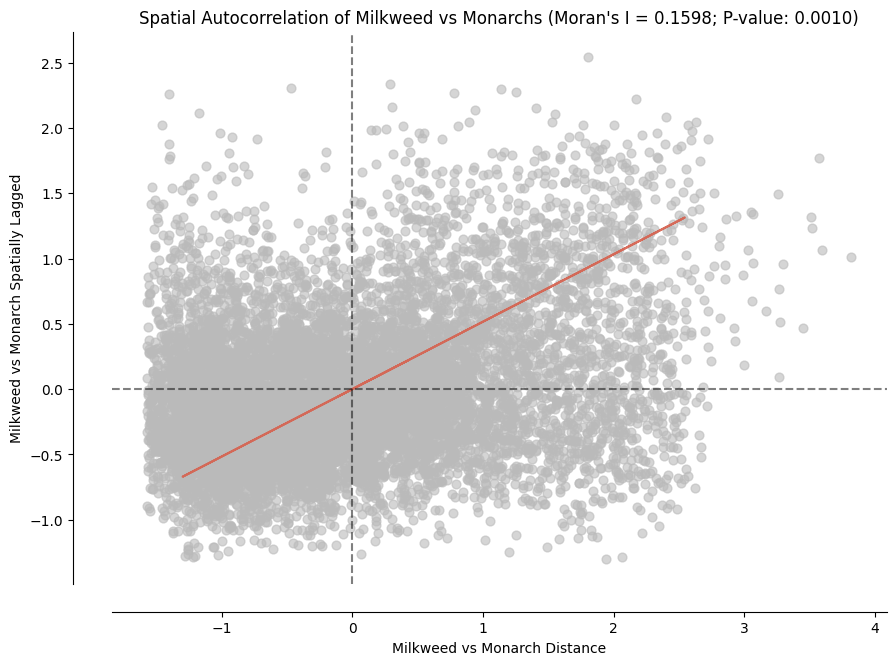

```python
# Converting DataFrame to a GeoDataFrame
gdf_milkweed = gpd.GeoDataFrame(sample_df_milkweed, geometry=gpd.points_from_xy(sample_df_milkweed.longitude_milkweed, sample_df_milkweed.latitude_milkweed))
gdf_monarch = gpd.GeoDataFrame(sample_df_milkweed, geometry=gpd.points_from_xy(sample_df_milkweed.longitude_monarch, sample_df_milkweed.latitude_monarch))

# Creating a spatial weights matrix
w = weights.Queen.from_dataframe(gdf_milkweed,use_index=False)

# Calculate Moran's I for monarch distance from milkweed
distance_monarch_milkweed = gdf_milkweed.distance(gdf_monarch.geometry)
moran_distance_monarch = esda.Moran(distance_monarch_milkweed, w)

# Visualize Moran's I scatterplot for monarch distance from temperature
fig, ax = plt.subplots(figsize=(10, 8))
moran_scatterplot(moran_distance_monarch, ax=ax)

# Set axis labels and title
ax.set_xlabel("Milkweed vs Monarch Distance")
ax.set_ylabel("Milkweed vs Monarch Spatially Lagged")
ax.set_title(f'Spatial Autocorrelation of Milkweed vs Monarchs (Moran\'s I = {moran_distance_monarch.I:.4f}; P-value: {moran_distance_monarch.p_sim:.4f})')

plt.show()
```

The x-axis represents the relationship between our two variables, while the y-axis represents the average value of its neighbors for the same variable.

As seen in the graph, there seems to be a slight correlation as if Milkweeds and Monarchs had zero correlation the data points would be completely randomly dispersed.

These results may imply that milkweed and butterfly have a detectable positive correlation.

In other words, the locations of milkweeds tend to be slightly associated with high local populations of monarch butterflies.

These findings coincide with the symbiotic relationship studied between monarchs and milkweeds as observed in our background research.

### Cold vs Hot Temperatures Geospatial Analysis using Moran's I

Unlike Milkweed populations, temperatures have distinct values so they can't really be randomized to minimize confounding variables.

Instead, to better analyze how different temperatures are related to Monarch Populations, we can separate temperature into three buckets: cold, normal, and hot, then compare the Moran's I value for each bucket.

We expect there to be some inherent spatial correlation because of inherent observational biases in the dataset, so our main interest is the difference in spatial correlation between the temperature buckets. Our method to measure this is by first computing the Moran's I for all temperatures, then measuring the Moran's I difference from that baseline to get the "relative Moran's I" value.

```python
# Shuffle the indices of monarch_df
monarch_indices = list(monarch_df.index)
random.shuffle(monarch_indices)

# Use shuffled indices to reorder rows of monarch_df
shuffled_monarch_df = monarch_df.iloc[monarch_indices].reset_index(drop=True)

# Merge temperature_df with shuffled_monarch_df
merged_df_temp = pd.merge(temperature_df, shuffled_monarch_df, on=['time'], how='inner', suffixes=('_temp', '_monarch'))

#filter to year range 2019-2024 for more reliable data
merged_df_temp = merged_df_temp[(merged_df_temp['time'].dt.year >= 2019)]

#take a sample of merged_df to minimize computation time
sample_df_temp = merged_df_temp.sample(10000, random_state=53)

#convert to readable temperature (celsius)
baseline_temp = 14
sample_df_temp['temperature'] += baseline_temp

sample_df_temp.head()
```

|  | time | latitude_temp | longitude_temp | temperature | region_temp | actual_temperature | latitude_monarch | longitude_monarch | region_monarch | species |
| --- | --- | --- | --- | --- | --- | --- | --- | --- | --- | --- |
| 27930791 | 2023-09-17 | 14.5 | -63.5 | 15.728043 | 16 | 15.728043 | 20.040150 | -100.723846 | 7 | monarch |
| 19799503 | 2022-03-18 | 29.5 | -78.5 | 14.967140 | 15 | 14.967140 | 26.343246 | -81.779381 | 15 | monarch |
| 13009372 | 2020-11-15 | 38.5 | -103.5 | 17.304041 | 23 | 17.304041 | 30.578348 | -103.909714 | 40 | monarch |
| 28887756 | 2023-09-17 | 52.5 | -103.5 | 18.245762 | 34 | 18.245762 | 41.157774 | -73.770012 | 3 | monarch |
| 5131558 | 2019-03-18 | 28.5 | -59.5 | 15.411119 | 42 | 15.411119 | 30.374570 | -86.138526 | 37 | monarch |

Lets take a look at the temperature statistics to evenly separate it into buckets.

```python
# Compute statistics for the "temperature" column
temperature_stats = sample_df_temp['temperature'].describe()

# Print the statistics
print(temperature_stats)
```

```
count    10000.000000
mean        15.127037
std          1.148204
min          7.920787
25%         14.536526
50%         14.974763
75%         15.577846
max         24.524977
Name: temperature, dtype: float64
```

Since temperature is generally normally distributed, lets use the standard deviation to split the buckets into:

Cold: 0.5 standard deviation below mean

Normal: 0.5 standard deviation within mean

Hot: 0.5 standard deviation above mean

```python
#get mean, stdev
mean = sample_df_temp['temperature'].describe()['mean']
stdev = sample_df_temp['temperature'].describe()['std']

# Define temperature ranges for the buckets
cold_range = (sample_df_temp['temperature'] < mean-0.5*stdev)
normal_range = (sample_df_temp['temperature'] >= mean-0.5*stdev) & (sample_df_temp['temperature'] <= mean+0.5*stdev)
hot_range = (sample_df_temp['temperature'] > mean+0.5*stdev)

# Create three separate DataFrames for cold, normal, and hot temperatures
cold_df = sample_df_temp[cold_range]
normal_df = sample_df_temp[normal_range]
hot_df = sample_df_temp[hot_range]
```

We have too many dataframes now so lets create a function to generate the Moran's I more efficiently:

```python
def generate_temp_morans(df,temp_bucket_name,baseline_morans):
    # Converting DataFrame to a GeoDataFrame
    gdf_temp = gpd.GeoDataFrame(df, geometry=gpd.points_from_xy(df.longitude_temp, df.latitude_temp))
    gdf_monarch = gpd.GeoDataFrame(df, geometry=gpd.points_from_xy(df.longitude_monarch, df.latitude_monarch))

    # Creating a spatial weights matrix
    w = weights.Queen.from_dataframe(gdf_temp,use_index=False)

    # Calculate Moran's I for monarch distance from milkweed
    distance_monarch_temp = gdf_temp.distance(gdf_monarch.geometry)
    moran_distance_monarch = esda.Moran(distance_monarch_temp, w)

    if(baseline_morans != 0):
        # Visualize Moran's I scatterplot for monarch distance from temperature
        fig, ax = plt.subplots(figsize=(10, 8))
        moran_scatterplot(moran_distance_monarch, ax=ax)
        # Set axis labels and title
        ax.set_xlabel(temp_bucket_name + " vs Monarch Distance")
        ax.set_ylabel(temp_bucket_name + " vs Monarch Spatially Lagged")
        ax.set_title(f'Spatial Autocorrelation of {temp_bucket_name} vs Monarchs (Relative Moran\'s I = {moran_distance_monarch.I-baseline_morans:.4f}; P-value: {moran_distance_monarch.p_sim:.4f})')

    return round(moran_distance_monarch.I,4)
```

```python
#generate moran's I for all temperatures to use as baseline
all_moran = generate_temp_morans(sample_df_temp,"All Temperatures",0)
print("Baseline Moran's I: " + str(all_moran))
```

```
Baseline Moran's I: 0.33
```

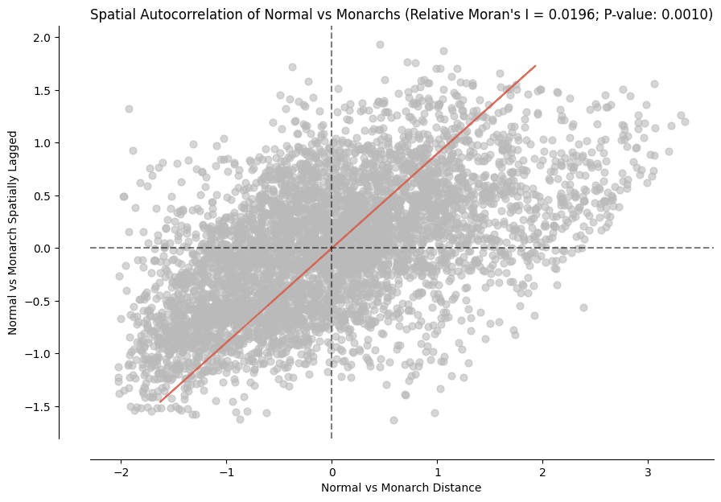

```python
#generate the relative moran's I normal temp moran's I
normal_morans = generate_temp_morans(normal_df,"Normal",all_moran)
```

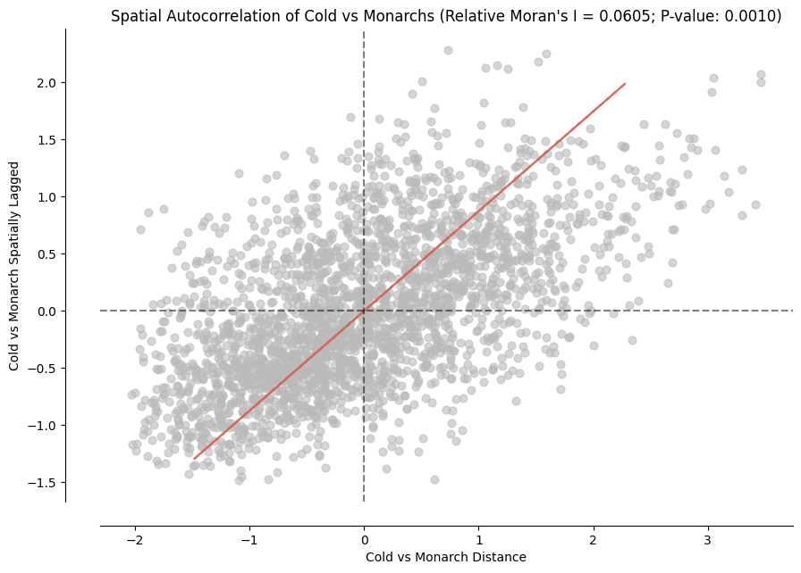

```python
#generate plot for cold moran's i
cold_morans = generate_temp_morans(cold_df,"Cold",all_moran)
```

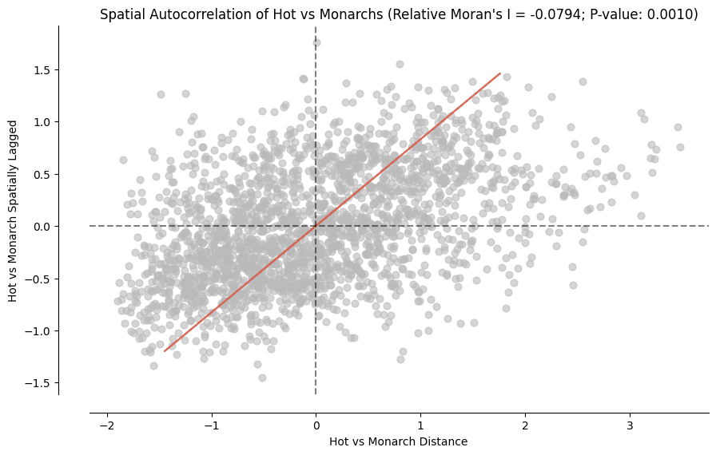

```python
#generate plot for hot moran's i
hot_morans = generate_temp_morans(hot_df,"Hot",all_moran)
```

Remember that there are inherent confounding variables in the data (observational biases, data is ordered by date) so we expected some inherent spatial correlation.

With that in mind we see that with all temperatures the baseline Moran's I is around 0.33.

Now we can compare how cold, normal, and hot global temperatures relate to monarch spatial correlation.

From these results, we can conclude that in comparison to the entire temperature dataset, monarch butterflies are slightly more spatially correlated with colder temperatures, while monarch butterflies are slightly less spatially correlated with hotter temperatures.

These results imply that Monarch populations are more geospatially clustered to colder areas, while they are more geospatially distant to hotter areas, compared to their clustering around normal temperatures.

These findings generally coincide with the fact that Monarch populations are a cold-blooded species, so they would prefer to cluster around colder temperatured areas while avoiding hotter temperatured areas.

## Time Series Analysis

For this analysis we wanted to conduct a time series analysis to model the correlation between both milkweed population and temperature against monarch count over time. We chose to use the SARIMAX (Seasonal Autoregressive Integrated Moving Average with eXogenous variables) model, which is used to model and forecast data that exhibit seasonal patterns and are influenced by external factors. In particular, we will be modeling milkweed_count vs monarch_count and temperature vs monarch_count.

### Create sarimax_df

To get the data in a format usable for SARIMAX analysis, we must modify the final dataframe slightly. First we grouped the temperature, milkweed counts, and monarch counts by month. We then adjusted the temperature column to reflect the actual temperature rather than the anomoloy from baseline. Finally, we filtered the date range based on what we observed in the EDA and set the time as the index.

```python
# aggregate temperature data on a monthly basis by region
temperature_monthly_avg = temperature_df.groupby([pd.Grouper(key='time', freq='M')]).temperature.mean().reset_index()

# aggregate milkweed counts on a monthly basis by region
milkweed_presence = milkweed_df.groupby([pd.Grouper(key='time', freq='M')]).size().reset_index(name='milkweed_count')

# aggregate monarch counts on a monthly basis by region
monarch_monthly_counts = monarch_df.groupby([pd.Grouper(key='time', freq='M')]).size().reset_index(name='monarch_count')

# merge aggregated temperature and milkweed counts on region and time
features_df = pd.merge(temperature_monthly_avg, milkweed_presence, on=['time'], how='outer').fillna({'presence': 0})

# merge the above with monarch counts to include monarch population data
sarimax_df = pd.merge(features_df, monarch_monthly_counts, on=['time'], how='left').fillna({'monarch_count': 0})

# drop null rows
sarimax_df = sarimax_df.dropna()

# adjust temperature column which is the temperature as an anomoly plus the baseline average
baseline_temperature = 14
sarimax_df['temperature'] = sarimax_df['temperature'] + baseline_temperature

# filter dates
start_date = pd.to_datetime('2019-01-01')
end_date = pd.to_datetime('2023-12-17')
sarimax_df = sarimax_df[(sarimax_df['time'] >= start_date) & (sarimax_df['time'] <= end_date)]

# set time as index
sarimax_df.set_index('time', inplace=True)
```

```python
sarimax_df.head()
```

| time | temperature | milkweed_count | monarch_count |
| --- | --- | --- | --- |
| 2019-01-31 | 15.021557 | 221 | 379 |
| 2019-02-28 | 13.663083 | 193 | 334 |
| 2019-03-31 | 14.524683 | 447 | 888 |
| 2019-04-30 | 14.788550 | 2584 | 1285 |
| 2019-05-31 | 14.329502 | 3319 | 1056 |

### Milkweed vs Monarch with SARIMAX

Using `auto_arima` from the `pdarima` package, we fit a SARIMAX model to the milkweed_count column and the monarch_count column. The benefit of using auto_arima is it automatically detects the optimal parameters for an ARIMA model. We set the `seasonal` parameter equal to true to account for the seasonality of monarch populations, and we set the `m` parameter equal to 12 to indicate monthly data with an annual seasonal cycle.

```python
y = sarimax_df['monarch_count']
X = sarimax_df['milkweed_count']

model = auto_arima(y, X=X.values.reshape(-1,1), seasonal=True, m=12, stepwise=True, suppress_warnings=True)
print(model.summary())
```

```
                                     SARIMAX Results
==========================================================================================
Dep. Variable:                                  y   No. Observations:                   59
Model:             SARIMAX(1, 0, 0)x(1, 1, 0, 12)   Log Likelihood                -378.100
Date:                            Mon, 18 Mar 2024   AIC                            764.199
Time:                                    16:36:59   BIC                            771.600
Sample:                                01-31-2019   HQIC                           766.984
                                     - 11-30-2023
Covariance Type:                              opg
==============================================================================
                 coef    std err          z      P>|z|      [0.025      0.975]
------------------------------------------------------------------------------
x1             0.2631      0.085      3.095      0.002       0.096       0.430
ar.L1          0.4945      0.090      5.516      0.000       0.319       0.670
ar.S.L12      -0.2047      0.083     -2.465      0.014      -0.367      -0.042
sigma2      5.476e+05   6.81e+04      8.045      0.000    4.14e+05    6.81e+05
===================================================================================
Ljung-Box (L1) (Q):                   0.02   Jarque-Bera (JB):                38.52
Prob(Q):                              0.89   Prob(JB):                         0.00
Heteroskedasticity (H):               1.43   Skew:                             0.85
Prob(H) (two-sided):                  0.48   Kurtosis:                         7.09
===================================================================================

Warnings:
[1] Covariance matrix calculated using the outer product of gradients (complex-step).
```

The coefficient for the milkweed_count is 0.2631, with a standard error of 0.085 and a p-value of 0.002. This indicates a statistically significant positive correlation between the milkweed_count and the monarch_count within this model.

### Temperature vs Monarch with SARIMAX

Using the same approach, we fit a SARIMAX model to the temperature column and the monarch_count column.

```python
y = sarimax_df['monarch_count']
X = sarimax_df['temperature']

model = auto_arima(y, X=X.values.reshape(-1,1), seasonal=True, m=12, stepwise=True, suppress_warnings=True)
print(model.summary())
```

```
                                     SARIMAX Results
==========================================================================================
Dep. Variable:                                  y   No. Observations:                   59
Model:             SARIMAX(1, 0, 0)x(0, 1, 0, 12)   Log Likelihood                -381.128
Date:                            Mon, 18 Mar 2024   AIC                            768.256
Time:                                    16:37:05   BIC                            773.806
Sample:                                01-31-2019   HQIC                           770.344
                                     - 11-30-2023
Covariance Type:                              opg
==============================================================================
                 coef    std err          z      P>|z|      [0.025      0.975]
------------------------------------------------------------------------------
x1            -6.0085    252.439     -0.024      0.981    -500.779     488.762
ar.L1          0.5960      0.069      8.696      0.000       0.462       0.730
sigma2      6.458e+05   9.52e+04      6.781      0.000    4.59e+05    8.32e+05
===================================================================================
Ljung-Box (L1) (Q):                   0.00   Jarque-Bera (JB):                25.13
Prob(Q):                              0.97   Prob(JB):                         0.00
Heteroskedasticity (H):               2.78   Skew:                             0.44
Prob(H) (two-sided):                  0.05   Kurtosis:                         6.47
===================================================================================

Warnings:
[1] Covariance matrix calculated using the outer product of gradients (complex-step).
```

# Ethics & Privacy

In the context of our project, three primary concerns have been identified: the prevalence of data in densely populated regions, the limitation of data collection to regions of North America, and the reliance on data from only two sources. Acknowledging and addressing these concerns is crucial to ensure the ethical conduct of our research, prevent biases, and foster equitable outcomes.

One significant concern revolves around the overrepresentation of observations in densely populated regions, potentially introducing biases that may not accurately reflect Monarch butterfly behaviors in less urbanized areas. Additionally, data stored from these sources may include people’s username as well as other personal information, but by filtering out these details we mitigate privacy concerns. Another concern involves the limitation of data collection to specific regions in North America, raising questions about the global applicability of our model and potential exclusion of diverse migration patterns from other continents. While in some cases this limitation could incur a sampling error/bias, considering Monarch’s are primarily found throughout North America, we do not anticipate it to skew any analysis we make from said data. The third concern revolves around relying on data from only two sources, posing the risk of introducing biases specific to those datasets and limiting the model's comprehensiveness.

By acknowledging and proactively addressing these concerns, our project endeavors to uphold ethical standards and contribute to a more equitable and well-rounded exploration of butterfly migration patterns.

# Discusison and Conclusion

## Revisit of Background and Prior Work

Previous studies have highlighted the potential impact of climate change and habitat loss on the migration patterns and population density of monarch butterflies. Factors such as changes in breeding ground distributions, variations in flight efficiency due to climate conditions, and loss of milkweed habitats have been identified as potential drivers of monarch population declines. Our research aimed to highlight the relationship between historic climate data, milkweed population data, and the migration patterns of monarchs, building upon the foundational work of researchers like Lemoine (2015), Cohen (2023), and Flockhart et al. (2015).

## Revisit of Hypotheses

H<sub>0</sub>: Historic aggregate air temperature and milkweed population data cannot predict the migration patterns and population density of Monarch butterflies in North America.

H<sub>a1</sub>: Historic aggregate air temperature data can predict the migration patterns and population density of Monarch butterflies in North America.

H<sub>a2</sub>: Milkweed population data can predict the migration patterns and population density of Monarch butterflies in North America.

## Limitations of the iNaturalist Data

While the iNaturalist dataset provided a valuable source of citizen science observations for monarch butterflies and milkweed plants, several limitations hindered our ability to establish a concrete connection between migration patterns and climate factors. Firstly, the data's reliability and completeness were uncertain due to the nature of citizen science contributions, potentially introducing biases and inconsistencies. Secondly, the temporal and spatial coverage of the observations was not sufficient to capture the full extent of monarch migration patterns across North America. Additionally, the available variables and metadata in the iNaturalist dataset were limited, lacking crucial information about environmental conditions and other factors that could influence migration.  
The shape of all iNaturalist data as such–that is, all species observations on iNaturalist–closely mirrors the shape of both the milkweed and monarch data; compare the Figures below:

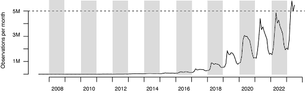

<sup>13</sup>

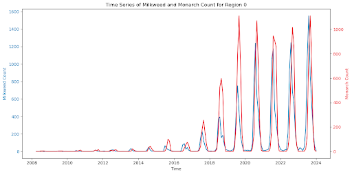

It is readily apparent that sampling error is present, likely contributing to the poor accuracy of our models, moreover supposing an inaccurate representation of milkweed and monarch populations. As to the possible reasons for the inordinate shape of the iNaturalist data, two are most prescient: (1) Referring back to the figures, between the years of 2008 and 2019 the number of observations is low; we then see an increase in observations by an order of magnitude in 2018 and onward. This likely attributed in part to the proliferation of technology, and access thereof, affording for better measurement tools and lowering the ceiling for those engaging in citizen science. Furthermore, the shape of the distribution is also attributed in part to the increase in popularity of the iNaturalist platform as such–which is ostensibly synchronized with the aforementioned technology boom. (2) Regarding human behavior, we see a decrease in iNaturalist observation during the latter portions of each calendar year and a corresponding increase near the middle portions (this is conjecture but for the sake of brevity, Q4 and Q1 for the former, Q2 and Q3 for the latter). This is likely attributed to poor weather conditions, inhibiting to-be observers from going outside and making observations. That is, we see increased observations during the summer months with a corresponding decrease in the winter months due to weather conditions.

## Lessons Learned and Future Directions

This research experience underscored the importance of reliable and high-quality data for ecological and climate-related studies. By combining multiple data sources and techniques, we may overcome the limitations faced in this study and gain a more comprehensive understanding of monarch migration patterns.

## Concluding Remarks

The culmination of our project has highlighted the ongoing importance of understanding the intricate relationships between species' migration, climate change, and habitat availability. By learning from the limitations faced in this study, we can pave the way for more impactful research that informs conservation strategies and mitigates the effects of environmental changes on vulnerable populations such as that of the Monarch Butterfly.

13. ^ 150,000,000 observations on iNaturalist!. *iNaturalist*. https://www.inaturalist.org/blog/82561-150-000-000-observations-on-inaturalist